# MineThatData Forecasting Challenge

sisifospage@gmail.com

10/31/2017

## Purpose

This markdown provides the complete R code for the proposed solution of [Sisifo’s page team](http://sisifospage.tech/) to the [MineThatData Forecasting Challenge](http://blog.minethatdata.com/2017/09/the-minethatdata-forecasting-challenge.html). The challenge is to forecast the next 3 months of a target time series that contains data of sales of an unknown company for 80 months. The proposed solution uses Bayesian Structural Time Series models, through the excellent open source library `bsts` by Steve Scott.

This solution was published at this [MineThatData blog post](http://blog.minethatdata.com/2017/11/the-minethatdata-forecasting-challenge_14.html) in Nov 15th 2017, and it got the best `squared error` of all solutions presented!!! (see [here](http://blog.minethatdata.com/2017/11/the-minethatdata-forecasting-challenge_16.html)).

If you are interested on the theoretical justification of the solution, some background about BSTS models and the way to use them (in particular, setting up Bayesian priors and doing cross-validation for time series, i.e. forward chaining), you can check the [whitepaper in pdf format](http://sisifospage.tech/docs/MineThatData_ForecastChallenge_whitepaper.pdf) that went along with the proposed solution.

### Loading the data

The data can be read directly from the excel file using the code below. Note that in the original file a few cells are duplicated (the ones corresponding to the month 41) and these duplicates are removed. A simple plot of the data is also provided.

```r
library(readxl)
library(httr)
GET("http://minethatdata.com/MineThatData_ForecastChallenge_20170914.xlsx",
    write_disk(tf <- tempfile(fileext = ".xlsx")))
```

```
## Response [http://minethatdata.com/MineThatData_ForecastChallenge_20170914.xlsx]
##   Date: 2017-12-03 17:03
##   Status: 200
##   Content-Type: application/vnd.openxmlformats-officedocument.spreadsheetml.sheet
##   Size: 21.8 kB
## <ON DISK>  /var/folders/lm/6kvyzp5d3ds_20dxw939n5hw0000gp/T//RtmpTHH0nN/file4fb92f432430.xlsx
```

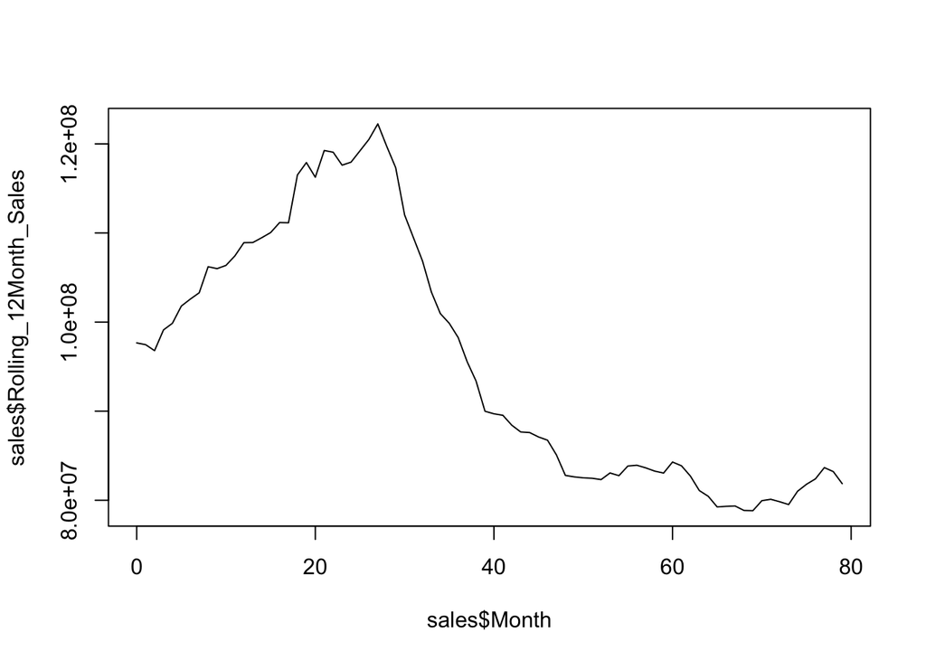

```r
sales <-
  read_excel(tf, sheet=1,
             col_names=TRUE, col_types=rep("numeric", 17))
sales <- sales[! duplicated(sales$Month),]
plot(sales$Month, sales$Rolling_12Month_Sales, type="l")
```

### Validation loop

How to setup the *Bayesian priors* for the model when you do not have clear priors? In the case of the Forecasting Challenge, there is not even any information at all about the business context. A possible strategies is to use `cross-validation`, but in a flavor adapted to time series, usually called `forward chaining` (see [this cross-validated answer](https://stats.stackexchange.com/a/14109/64316) or [this blog post](https://robjhyndman.com/hyndsight/tscv/)).

The following code adopts the strategy for a `bsts` model, where:

- `data` is the full dataset
- `horizon` refers to the prediction horizon
- `number_of_folds` i.e. number of loops of `forward chaining`
- `ss.function` is a function for defining the `state.specification` of the `bsts` model; a function is needed since the `state.specification` component needs to be trained (it extracts some parameters from the available data, while the training data changes in every iteration of the loop)
- `niter`, `seed` and `burn`: see ?bsts
- the rest are for debugging and visualization

The loop implements 3 measures, the *root mean square deviation*, and some other measures commonly used in time series prediction, *mape* and *mase*.

```r
library(bsts)
```

```r
# cross-validation loop
bsts.cv.loop <- function(data,
                         horizon,
                         number_of_folds,
                         ss.function,
                         niter=1000,
                         seed=1232,
                         burn=250,
                         do.plot=TRUE,
                         verbose=TRUE,
                         debug=TRUE) {
  rmse_v <- c()
  mape_v <- c()
  mase_v <- c()
  for (fold in 1:number_of_folds) {
    # construct data_train/data_test
    l <- length(data) - fold*horizon
    if (debug) print(l)
    data_train <- data[1:l]
    data_test <- data[(l+1):(l+horizon)]
    # fit model & predict
    model <- bsts(data_train,
                  state.specification=ss.function(data_train),
                  niter=1000,
                  seed=1232,
                  ping=0)
    pred <- predict(model, horizon=horizon, burn=burn)
    if (do.plot) {
      # plot
      plot(pred, plot.original = 36)
      lines((l+1):(l+horizon), data_test, col="red", type="l")
    }
    # evaluation
    errors <- data_test-pred$mean
    rmse <- sqrt(mean(errors^2))
    rmse_v <- c(rmse_v, rmse)
    mape <- mean(abs(errors)/data_test)*100
    mape_v <- c(mape_v, mape)
    naive_prediction_errors <- diff(data, 1)
    mase <- mean(abs(errors)) / mean(abs(naive_prediction_errors))
    mase_v <- c(mase_v, mase)
    if (verbose) print(paste0("fold ", fold, ": mape ", mape, " / mase ", mase))
  }
  return(data.frame(rmse=rmse_v,mape=mape_v, mase=mase_v))
}
```

### Initialization

```r
# 0. setup
# 0.1. target series to predict, ordered by month
target <- sales$Rolling_12Month_Sales[order(sales$Month)]
plot(target, type="l")

# 0.2. general parameters for the prediction
horizon=3 # as in Hillstron's challenge
number_of_folds=8 # reserves around 70% of the data for training only
```

### Selecting the right trend component and its parameters

After implementing the cross-validation loop, selecting the best trend component, together with its parameters, is a matter of brute force.

In the following loop, the validation is done for the `local level` trend component, which is the simplest and has only a parameter to set.

```r
# 1.1. fit "local level" and set best prior values
res_df1 <- c()
for (sigma_guess in c(0.01, 0.1, 0.5)) {
  res <-
    bsts.cv.loop(target,
                 horizon=horizon,
                 number_of_folds=number_of_folds,
                 ss.function=function(data_train) {
                   sdy <- sd(data_train)
                   sd.prior <- SdPrior(sigma.guess=sigma_guess*sdy,
                                       upper.limit=sdy,
                                       sample.size=16)
                   return(AddLocalLevel(list(),
                                        data_train,
                                        sigma.prior=sd.prior))
                 },
                 debug=FALSE,
                 verbose=FALSE)
  print(paste0("sigma_guess ", sigma_guess,
               ": mean(rmse) ", mean(res$rmse),
               " / mean(mape) ", mean(res$mape),
               " / mean(mase) ", mean(res$mase)))
  res_row <- data.frame(sigma_guess=sigma_guess,
                        mean_rmse=mean(res$rmse),
                        mean_mape=mean(res$mape),
                        mean_mase=mean(res$mase))
  res_df1 <- rbind(res_df1, res_row)
}
res_df1
write.csv(res_df1, file="cv_res_local_level.csv",
          row.names=FALSE)
```

This is the result. Differences of the fit for the values of the parameters are quite minimal.

```r
res_df1
```

```
##   sigma_guess mean_rmse mean_mape mean_mase
## 1        0.01   1113079  1.296845 0.9144091
## 2        0.10   1113191  1.296731 0.9143498
## 3        0.50   1121630  1.302850 0.9187451
```

In a second loop, the `local linear` trend component is tested. In this one, two parameters are set in a nested loop.

```r
# 1.2. fit "local linear" and set best prior values
res_df2 <- c()
for (level_sigma_guess in c(0.01, 0.1, 0.5)) {
  for (slope_sigma_guess in c(0.01, 0.1, 0.5)) {
    res <-
      bsts.cv.loop(target,
                   horizon=horizon,
                   number_of_folds=number_of_folds,
                   ss.function=function(data_train) {
                     sdy <- sd(data_train)
                     sigma.prior <- SdPrior(sigma.guess=level_sigma_guess*sdy,
                                            upper.limit=sdy,
                                            sample.size=16)
                     slope.sigma.prior <- SdPrior(sigma.guess=slope_sigma_guess*sdy,
                                                  upper.limit=sdy,
                                                  sample.size=16)
                     return(AddLocalLinearTrend(list(),
                                                data_train,
                                                level.sigma.prior=sigma.prior,
                                                slope.sigma.prior=slope.sigma.prior))
                   },
                   debug=FALSE,
                   verbose=FALSE)
    print(paste0("level_sigma_guess ", level_sigma_guess, " / slope_sigma_guess ", slope_sigma_guess,
                 ": mean(rmse) ", mean(res$rmse),
                 " / mean(mape) ", mean(res$mape),
                 " / mean(mase) ", mean(res$mase)))
    res_row <- data.frame(level_sigma_guess=level_sigma_guess,
                          slope_sigma_guess=slope_sigma_guess,
                          mean_rmse=mean(res$rmse),
                          mean_mape=mean(res$mape),
                          mean_mase=mean(res$mase))
    res_df2 <- rbind(res_df2, res_row)
  }
}
res_df2
write.csv(res_df2, file="cv_res_local_linear_level.csv",
          row.names=FALSE)
```

Note that this component works consistently worse than the `local level` for the series in hand.

```r
res_df2
```

```
##   level_sigma_guess slope_sigma_guess mean_rmse mean_mape mean_mase
## 1              0.01              0.01   1364297  1.481599 1.0443783
## 2              0.01              0.10   1703694  1.840721 1.3013977
## 3              0.01              0.50   1744992  1.929831 1.3665115
## 4              0.10              0.01   1211363  1.331118 0.9428945
## 5              0.10              0.10   1577616  1.690251 1.1950030
## 6              0.10              0.50   1737569  1.918044 1.3579408
## 7              0.50              0.01   1244229  1.361862 0.9660299
## 8              0.50              0.10   1230068  1.311644 0.9268897
## 9              0.50              0.50   1624604  1.758403 1.2439698
```

Finally, the `semi-local linear` is tried. This is the most complex trend component available in the library, and has 4 parameters to set.

```r
res_df3 <- c()
for (level_sigma_guess in c(0.01, 0.1, 0.5)) {
  for (slope_mean_guess in c(0.01, 0.1, 0.5)) {
    for (slope_sigma_guess in c(0.01, 0.1, 0.5)) {
      for (ar_sigma_guess in c(0.01, 0.1, 0.5, 1)) {
        res <-
          bsts.cv.loop(target,
                       horizon=horizon,
                       number_of_folds=number_of_folds,
                       ss.function=function(data_train) {
                         sdy <- sd(data_train)
                         sigma.prior <- SdPrior(sigma.guess=level_sigma_guess*sdy,
                                                upper.limit=sdy,
                                                sample.size=16)
                         slope.mean.prior <- NormalPrior(mu=0,
                                                         sigma=slope_mean_guess*sdy)
                         slope.ar1.prior <- Ar1CoefficientPrior(mu=0,
                                                                sigma=1*ar_sigma_guess)
                         slope.sigma.prior <- SdPrior(sigma.guess=slope_sigma_guess*sdy,
                                                      upper.limit=sdy,
                                                      sample.size=16)
                         return(AddSemilocalLinearTrend(list(),
                                                        data_train,
                                                        level.sigma.prior=sigma.prior,
                                                        slope.mean.prior=slope.mean.prior,
                                                        slope.ar1.prior=slope.ar1.prior,
                                                        slope.sigma.prior=slope.sigma.prior))
                       },
                       debug=FALSE,
                       verbose=FALSE)
        print(paste0("level_sigma_guess ", level_sigma_guess,
                     " / slope_mean_guess ", slope_mean_guess,
                     " / slope_sigma_guess ", slope_sigma_guess,
                     " / ar_sigma_guess ", ar_sigma_guess,
                     ": mean(rmse) ", mean(res$rmse),
                     " / mean(mape) ", mean(res$mape),
                     " / mean(mase) ", mean(res$mase)))
        res_row <- data.frame(level_sigma_guess=level_sigma_guess,
                              slope_mean_guess=slope_mean_guess,
                              slope_sigma_guess=slope_sigma_guess,
                              ar_sigma_guess=ar_sigma_guess,
                              mean_rmse=mean(res$rmse),
                              mean_mape=mean(res$mape),
                              mean_mase=mean(res$mase))
        res_df3 <- rbind(res_df3, res_row)
      }
    }
  }
}
res_df3
write.csv(res_df3, file="cv_res_semi_local_linear_level.csv",
          row.names=FALSE)
```

The following are the values around the minimum. Note that there are only slightly better than the ones for the `local level` component; anyhow, the prediction with horizon 3 is going to be much more sensible for the `semi-local linear`, since the series is modeled as trend only.

```r
res_df3[res_df3$mean_mape <= min(res_df3$mean_mape)*1.01 &
          res_df3$mean_mape >= min(res_df3$mean_mape)*0.99,]
```

```
##    level_sigma_guess slope_mean_guess slope_sigma_guess ar_sigma_guess
## 14              0.01             0.10              0.01            0.1
## 26              0.01             0.50              0.01            0.1
## 39              0.10             0.01              0.01            0.5
## 40              0.10             0.01              0.01            1.0
## 51              0.10             0.10              0.01            0.5
## 63              0.10             0.50              0.01            0.5
## 64              0.10             0.50              0.01            1.0
##    mean_rmse mean_mape mean_mase
## 14   1102451  1.204493 0.8541107
## 26   1105388  1.205426 0.8548579
## 39   1111522  1.204680 0.8514994
## 40   1110975  1.204386 0.8512959
## 51   1102954  1.211028 0.8554464
## 63   1104017  1.211963 0.8562478
## 64   1102445  1.210628 0.8552218
```

### Chosen model

This is a final fit of the chosen model, with the trend component and its parameters as selected in the section above, for obtaining the predictions.

```r
sdy <- sd(target)
level.sigma.prior <- SdPrior(sigma.guess=0.01*sdy,
                       upper.limit=sdy,
                       sample.size=16)
slope.ar1.prior <- Ar1CoefficientPrior(mu=0,
                                       sigma=0.1)
slope.mean.prior <- NormalPrior(mu=0,
                                sigma=0.1*sdy)
slope.sigma.prior <- SdPrior(sigma.guess=0.01*sdy,
                             upper.limit=sdy,
                             sample.size=16)
state.specification <- AddSemilocalLinearTrend(list(),
                                               target,
                                               level.sigma.prior=level.sigma.prior,
                                               slope.ar1.prior=slope.ar1.prior,
                                               slope.mean.prior=slope.mean.prior,
                                               slope.sigma.prior=slope.sigma.prior)
chosen_model <- bsts(target,
                     state.specification=state.specification,
                     niter=1000,
                     seed=1232)
pred <- predict(chosen_model, horizon = 3, burn = 250)
```

This is a simple analysis of the residuals; results look reasonable. There’s a very weak annual seasonality, already detected in the exploratory analysis, which is not captured by the trend-only model.

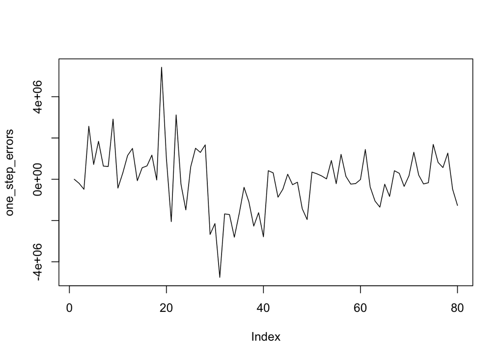

```r
one_step_errors <- colMeans(chosen_model$one.step.prediction.errors)
plot(one_step_errors, type="l")
```

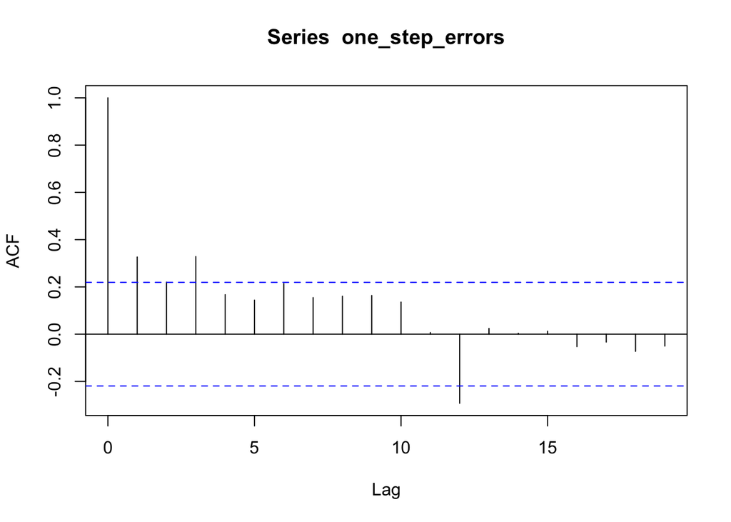

```r
acf(one_step_errors)
```

And finally this is a plot of the predictions; certainty margins are quite wide, but still it looks reasonable for a trend-only model.

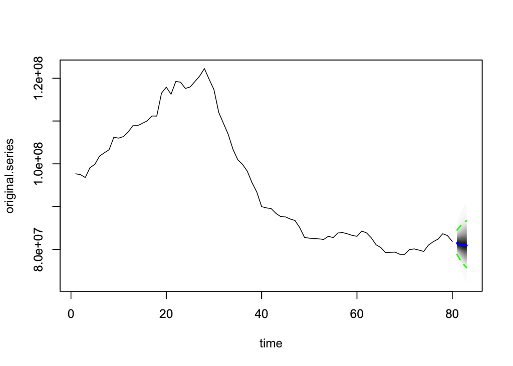

```r
plot(pred, plot.original = 80)
```

```r
pred$mean
```

```
## [1] 81532403 81236545 81002410
```